# SBW25 variants

```r
library(here)
library(tidyverse)
library(latex2exp)
library(clusterProfiler)
library(future.apply)
library(qvalue)
library(patchwork)
source("parallelism_utils.R")
```

# LOAD DATA

## VARIANTS

```r
pfanc =
  read_tsv(here::here("variant_calls", "Pf_ANC.ASM922.final.tsv"))
pfE1 =
  left_join(read_tsv(here::here(
    "variant_calls", "Pf_E1.ASM922.final.tsv"
  )), read_delim(
    here::here("variant_calls", "Pf_E1.ASM922.hapfreq.tsv"),
    col_names = c(
      "CHROM",
      "FILTER",
      "POS",
      "ALLELENUM",
      "REFALLELE",
      "ALTALLELE",
      "PHASEGROUP",
      "GT",
      "ALLELEDEPTH",
      "ALLELEFREQ",
      "MAP_HAPFREQ"
    )
  )) %>% mutate(replicate="pfE1")
pfE2 =
  left_join(read_tsv(here::here(
    "variant_calls", "Pf_E2.ASM922.final.tsv"
  )), read_delim(
    here::here("variant_calls", "Pf_E2.ASM922.hapfreq.tsv"),
    col_names = c(
      "CHROM",
      "FILTER",
      "POS",
      "ALLELENUM",
      "REFALLELE",
      "ALTALLELE",
      "PHASEGROUP",
      "GT",
      "ALLELEDEPTH",
      "ALLELEFREQ",
      "MAP_HAPFREQ"
    )
  )) %>% mutate(replicate="pfE2")
pfE3 =
  left_join(read_tsv(here::here(
    "variant_calls", "Pf_E3.ASM922.final.tsv"
  )), read_delim(
    here::here("variant_calls", "Pf_E3.ASM922.hapfreq.tsv"),
    col_names = c(
      "CHROM",
      "FILTER",
      "POS",
      "ALLELENUM",
      "REFALLELE",
      "ALTALLELE",
      "PHASEGROUP",
      "GT",
      "ALLELEDEPTH",
      "ALLELEFREQ",
      "MAP_HAPFREQ"
    )
  )) %>% mutate(replicate="pfE3")
```

As supplementary dataset

```r
df.final <- bind_rows(pfE1, pfE2, pfE3) %>%
  anti_join(., dplyr::select(pfanc, CHROM, POS)) %>%
  mutate(SPECIES="Pseudomonas fluorescens SBW25") %>%
  separate(ALLELEFREQ, into=c("REF.FREQ", "ALT.FREQ"), sep=",") %>%
  separate(MAP_HAPFREQ, into=c("HAP1.FREQ", "HAP2.FREQ", "HAP3.FREQ"), sep=",") %>%
  select(SPECIES, REPLICATE=replicate, POS, REF, ALT, FILTER, ALLELENUM, GENOTYPE=GT, REF.FREQ, ALT.FREQ, PHASEGROUP, HAP1.FREQ, HAP2.FREQ, HAP3.FREQ, FTYPE:PRODUCT) %>%
  arrange(POS)
write_tsv(df.final, here::here("results", "final_variants.tsv"))
```

# MULTIPLICITY

Crude first look at which genes are mutated in more than one replicate population

```r
mult1 <- df.final %>%
  group_by(REPLICATE, LOCUS_TAG) %>%
  slice(1) %>%
  ungroup() %>%
  add_count(LOCUS_TAG) %>%
  arrange(desc(n), LOCUS_TAG, REPLICATE) %>%
  select(REPLICATE, POS, REF, ALT, LOCUS_TAG, PRODUCT)
```

# Parallelism at nucleotide level

From Good 2017: At the most fine-grained functional level, we also searched for signatures of parallelism by looking for independent mutations that occurred at the same site in the genome. Because it is difficult to resolve independent appearances of an allele in the same population, we focused on sites that were mutated in multiple replicate populations. We also excluded indels and structural variants, due to the difficulty in assigning a consistent nucleotide site to these complex mutation events. Our analysis therefore represents a lower bound on the amount of nucleotide-level parallelism in the LTEE.

## Nucleotide multiplicity.

```r
df.final %>%
  group_by(POS, REF, ALT) %>%
  summarize(mi=n()) %>%
  ungroup() %>%
  count(mi)
```

| mi | n |
| --- | --- |
| 1 | 632 |
| 2 | 11 |
| 3 | 5 |

So there are 5 sites where the same mutation occurred in 3 independent lines, 11 sites where the same mutation occurred in 2 independent lines, and 632 sites where the mutation was unique in one population.

To put these observations in context, we can compare them to a null model in which mutations are uniformly distributed across the sites in the genome. In this model, the expected fraction of mutations with multiplicity≥min a sample of size $n_{tot}$ is given by

$S(m) \approx \sum\limits_{n \geq m} \frac{n}{n_{tot}} \times L_{tot} \times \frac{ \left( \frac{n_{tot}}{L_{tot}} \right) ^n}{n!} \times e^{-n_{tot}/L_{tot}}$

```r
allele_mult <- df.final %>%
  group_by(POS, REF, ALT) %>%
  summarize(mi=n()) %>%
  ungroup() %>%
  count(mi, name="Survival_Observed") %>%
  mutate(ntot = sum(Survival_Observed)) %>%
  mutate(poisson_pmf = poisson_pmf(mi-1, ntot)) %>%
  arrange(desc(mi)) %>%
  mutate(poisson_survive=cumsum(poisson_pmf)) %>%
  mutate(Survival_Expected=ntot*poisson_survive) %>%
  select(mi, Survival_Expected, Survival_Observed) %>%
  pivot_longer(-mi) %>%
  mutate(name=factor(name, levels=c("Survival_Observed", "Survival_Expected"),
                     labels= c("Survival Observed", "Survival Expected")))
```

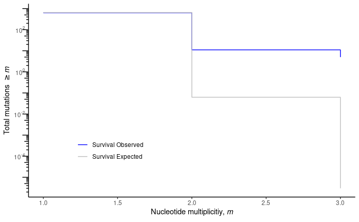